# 用R做統合分析

長庚資管 曾意儒 Yi-Ju Tseng / 黃詩茜

## 大綱

- 統合分析使用套件
- 什麼是統合分析
- 統合分析步驟
  - 文獻搜尋
  - 文獻篩選
  - 統合分析

### 統合分析使用套件

- 統合分析相關
  - metagear [教學](http://lajeunesse.myweb.usf.edu/metagear/metagear_basic_vignette.html)
  - RISmed [教學](https://amunategui.github.io/pubmed-query/)
  - metafor [官方文件](https://wviechtb.github.io/metafor/index.html)
- 資料處理相關
  - dplyr [官方網站](https://dplyr.tidyverse.org/)

### 什麼是Review？系統性回顧？

將某一個主題相關的文獻搜尋、統整，進一步做出結論。

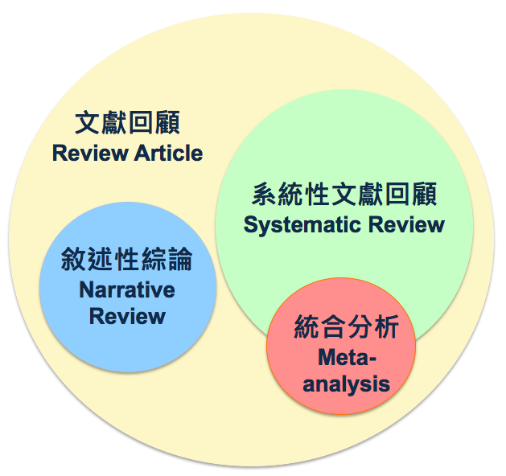

### 什麼是Review？系統性回顧？

文獻回顧的方式分成兩種：

- 敘述性綜論
- 系統性文獻回顧

### 什麼是系統性回顧？

- 依照標準的程序來作文獻搜尋、篩選，做出結論或建議
- 「系統性文獻回顧」是一個操作的過程
- meta-analysis是「系統性文獻回顧」中，可以利用的統計工具

### 什麼是統合分析meta-analysis？

- “The analysis of analyses”
  - Gene V. Glass Primary, secondary and meta-analysis of research, Educational Researcher, 1976.
- 大量蒐集個別研究的分析結果，作統計分析
- 使用相同的統計方法評論大量的研究結果

### 什麼是統合分析meta-analysis？

A meta-analysis is the synthesis of:

- `K` compatible **effects**
  - Mean, Mean difference, Mean change
  - Risk ratio, Odds ratio, Risk difference
  - Incidence rate, Prevalence, Proportion
  - Correlation
- Giving greater weight to studies with:
  - Less variance
  - More precision

### 什麼是統合分析meta-analysis？

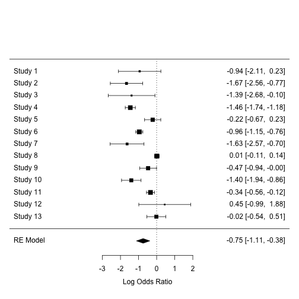

### 統合分析步驟

- 文獻搜尋
- 資料萃取
- 統計分析
- 出版偏差評估

## 文獻搜尋

- Keywords
- Data-based exhausted search
- Abstract screening

### Keywords

- (K1) and (K2)
- (K1 or A1) and (K2 or A2)
- 文章太多的話: (K1) and (K2) and (K3)

### Data-based exhausted search

- PubMed – `RISmed` package
- Scopus – 下載輸出
- Medline – 下載輸出
- Cochrane – 下載輸出

### PubMed – `RISmed` package

`EUtilsSummary( query, db, search.limits)`

- `query`: String query as given on PubMed site
- `db`: String name of NCBI database
- `search.limits`: Additional arguments to restrict search

### PubMed – `RISmed` package

```r
library(RISmed)
fit <- EUtilsSummary("rofecoxib[ti]+British Medical Journal[jo]", db = "pubmed")
summary(fit)
```

```
Query:
rofecoxib[ti] AND ("Br Med J"[Journal] OR "Br Med J (Clin Res Ed)"[Journal] OR "BMJ"[Journal])

Result count:  16
```

```r
QueryTranslation(fit)
```

```
[1] "rofecoxib[ti] AND (\"Br Med J\"[Journal] OR \"Br Med J (Clin Res Ed)\"[Journal] OR \"BMJ\"[Journal])"
```

```r
QueryCount(fit)
```

```
[1] 16
```

### PubMed – `RISmed` package

`EUtilsGet`: 取得查詢結果

```r
fetch <- EUtilsGet(fit)
ArticleTitle(fetch)[1:3]
```

```
[1] "Merck pays $1bn penalty in relation to promotion of rofecoxib."
[2] "Merck to pay $58m in settlement over rofecoxib advertising."
[3] "94% of patients suing Merck over rofecoxib agree to company's offer."
```

```r
Author(fetch)[[1]]
```

```
  LastName       ForeName Initials order
1    Tanne Janice Hopkins       JH     1
```

### PubMed – `RISmed` package

將重要資訊整理成`data.frame`

```r
pubmed_data <-
  data.frame(Title=ArticleTitle(fetch),
             Abstract=AbstractText(fetch),
             PMID=PMID(fetch),
             ELocationID=ELocationID(fetch),
             Language=Language(fetch),
             stringsAsFactors = F)
knitr::kable(pubmed_data)
```

| Title | Abstract | PMID | ELocationID | Language |
| --- | --- | --- | --- | --- |
| Merck pays $1bn penalty in relation to promotion of rofecoxib. |  | 22123916 | 10.1136/bmj.d7702 | eng |
| Merck to pay $58m in settlement over rofecoxib advertising. |  | 18511780 | 10.1136/bmj.39591.705231.DB | eng |
| 94% of patients suing Merck over rofecoxib agree to company's offer. |  | 18340064 | 10.1136/bmj.39513.541296.DB | eng |
| Merck to pay $5bn in rofecoxib claims. |  | 18006982 | NA | eng |
| Merck appeals rofecoxib verdict. |  | 17379897 | NA | eng |
| Court awards claimant 13.5m dollars in rofecoxib lawsuit. |  | 16627492 | NA | eng |
| Merck faces ongoing claims after Texan ruling on rofecoxib. |  | 16141139 | NA | eng |
| Differences in outcomes of patients with congestive heart failure prescribed celecoxib, rofecoxib, or non-steroidal anti-inflammatory drugs: population based study. | OBJECTIVES: To compare the risk of death and recurrent congestive heart failure in elderly patients prescribed celecoxib, rofecoxib, or non-steroidal anti-inflammatory drugs (NSAIDs) and to determine … | 15947399 | NA | eng |
| Lessons from the withdrawal of rofecoxib: Observational studies should not be forgotten. |  | 15576749 | NA | eng |
| Lessons from the withdrawal of rofecoxib: France has policy for overall assessment of public health impact of new drugs. |  | 15576748 | NA | eng |
| UK patients seek compensation after taking rofecoxib. |  | 15576740 | NA | eng |
| US government agency to investigate FDA over rofecoxib. |  | 15499092 | NA | eng |
| Lessons from the withdrawal of rofecoxib. |  | 15485938 | NA | eng |
| Celecoxib, rofecoxib, and acute temporary visual impairment. |  | 14630760 | NA | eng |
| Are selective COX 2 inhibitors superior to traditional NSAIDs? Rofecoxib did not provide unequivocal benefit over traditional NSAIDs. |  | 12130617 | NA | eng |
| FDA warns Merck over its promotion of rofecoxib. |  | 11588068 | NA | eng |

### PubMed – `RISmed` package

資料初步處理後備用

```r
library(dplyr)
#選擇語言為英文的文獻
pubmed_data <-
  filter(pubmed_data, Language == "eng")
colnames(pubmed_data) <-
  c("TITLE","ABSTRACT",
    "PMID","DOI","Language")
pubmed_data$Source <- "PubMed"
```

### Scopus – 下載輸出

檔案類型為csv檔

[figure not shown]

### Scopus – 下載輸出

檔案類型為csv檔

[figure not shown]

### Medline – 下載輸出

檔案類型為xls檔

[figure not shown]

### Cochrane – 下載輸出

檔案類型為txt檔

[figure not shown]

### 整理所有資料庫搜尋結果

- 整理DOI與PMID的欄位，如去除前後空白等，方便進行比對重複文獻
- 去除TITLE或ABSTRACT為`NA`，PMID與DOI**皆為**`NA`的文獻
- 去除重複出現的文獻
- 最後將data.frame存起來供未來使用

### Abstract Screening Tool

- 幫忙紀錄論文篩選結果
  - Excel
  - `metagear` package

### metagear package

metagear使用範例，實際使用時應為上述步驟整理好的檔案

```r
library(metagear)
example<-example_references_metagear
knitr::kable(head(example))
```

- [Mac安裝metagear會遇到的問題](https://stackoverflow.com/questions/44013379/installing-rgtk2-on-macos-sierra-version-10-12-4-and-r-version-3-4-0)

### metagear package

```r
#輸入審查者名稱
theTeam <- c("sch","yjt")
#載入檔案
paperScreened <-
  effort_initialize(example)

#審查者的分工方式:平均分配
paperDistribute <-
  effort_distribute(paperScreened,
                    initialize = FALSE,
                    reviewers = theTeam,
                    effort = c(50, 50),
                    save_split = TRUE)
```

### Abstract screening

```r
#所有文獻交由第一位審查者審查
paperTogether_1 <-
  effort_distribute(paperScreened,
                    initialize = FALSE,
                    reviewers = theTeam,
                    effort = c(100, 0),
                    save_split = TRUE)
#20%的文獻由第一位審查者審查；80%的文獻由第二位審查者審查
paperTogether_2 <-
  effort_distribute(paperScreened,
                    initialize = FALSE,
                    reviewers = theTeam,
                    effort = c(20, 80),
                    save_split = TRUE)
```

### metagear package

```r
#abstract_screener()開啟審查視窗
abstract_screener("effort_sch.csv",
                  aReviewer = "sch")
```

### metagear package

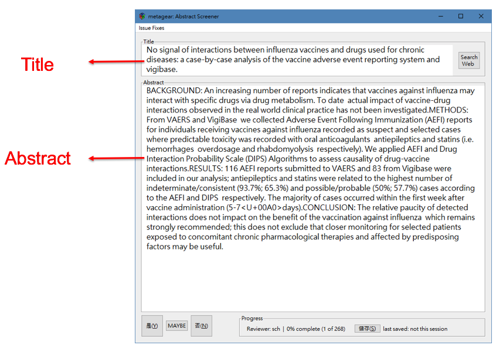

### PRISMA statement

[PRISMA statement](http://www.prisma-statement.org/)

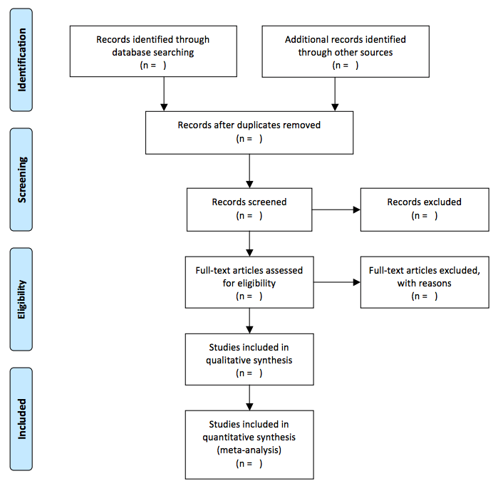

### 資料萃取

- 「人數、平均數、標準差」（介入性研究，Outcome為連續變項）
- 「人數、發生事件人數」（介入性研究，Outcome為二元變項）
- 「勝算比及信賴區間」（觀察型研究，Outcome為二元變項）
- 類別變項 (Odds ratio)
- 連續變項但單位不同 (SMD)
- 連續變項單位相同 (Diff in means)

## 統計分析

- Summary effect
- Assess heterogeneity
- Subgroup analysis
- Sensitivity analysis

### 載入練習用資料

number of TB pos/neg cases

```r
library(metafor)
# BCG meta-analytic dataset
data(dat.bcg)
knitr::kable(dat.bcg)
```

| trial | author | year | tpos | tneg | cpos | cneg | ablat | alloc |
| --- | --- | --- | --- | --- | --- | --- | --- | --- |
| 1 | Aronson | 1948 | 4 | 119 | 11 | 128 | 44 | random |
| 2 | Ferguson & Simes | 1949 | 6 | 300 | 29 | 274 | 55 | random |
| 3 | Rosenthal et al | 1960 | 3 | 228 | 11 | 209 | 42 | random |
| 4 | Hart & Sutherland | 1977 | 62 | 13536 | 248 | 12619 | 52 | random |
| 5 | Frimodt-Moller et al | 1973 | 33 | 5036 | 47 | 5761 | 13 | alternate |
| 6 | Stein & Aronson | 1953 | 180 | 1361 | 372 | 1079 | 44 | alternate |
| 7 | Vandiviere et al | 1973 | 8 | 2537 | 10 | 619 | 19 | random |
| 8 | TPT Madras | 1980 | 505 | 87886 | 499 | 87892 | 13 | random |
| 9 | Coetzee & Berjak | 1968 | 29 | 7470 | 45 | 7232 | 27 | random |
| 10 | Rosenthal et al | 1961 | 17 | 1699 | 65 | 1600 | 42 | systematic |
| 11 | Comstock et al | 1974 | 186 | 50448 | 141 | 27197 | 18 | systematic |
| 12 | Comstock & Webster | 1969 | 5 | 2493 | 3 | 2338 | 33 | systematic |
| 13 | Comstock et al | 1976 | 27 | 16886 | 29 | 17825 | 33 | systematic |

### 其他範例資料

mean difference

```r
knitr::kable(dat.ishak2007)
```

| study | y1i | v1i | y2i | v2i | y3i | v3i | y4i | v4i | mdur | mbase |
| --- | --- | --- | --- | --- | --- | --- | --- | --- | --- | --- |
| Alegret (2001) | -33.4 | 14.3 | NA | NA | NA | NA | NA | NA | 16.1 | 53.6 |
| Barichella (2003) | -20.0 | 7.3 | NA | NA | -30.0 | 5.7 | NA | NA | 13.5 | 45.3 |
| Berney (2002) | -21.1 | 7.3 | NA | NA | NA | NA | NA | NA | 13.6 | 45.6 |
| Burchiel (1999) | -20.0 | 8.0 | -20.0 | 8.0 | -18.0 | 5.0 | NA | NA | 13.6 | 48.0 |
| Chen (2003) | NA | NA | -32.9 | 125.0 | NA | NA | NA | NA | 12.1 | 65.7 |
| DBS for PD Study Grp. (2001) | -25.6 | 4.2 | -28.3 | 4.6 | NA | NA | NA | NA | 14.4 | 54.0 |
| Dujardin (2001) | -30.3 | 88.2 | NA | NA | -24.5 | 170.7 | NA | NA | 13.1 | 65.0 |
| Esselink (2004) | NA | NA | -25.0 | 17.0 | NA | NA | NA | NA | 12.0 | 51.5 |
| Funkiewiez (2003) | NA | NA | NA | NA | -36.0 | 5.0 | NA | NA | 14.0 | 56.0 |
| Herzog (2003) | NA | NA | -22.5 | 6.8 | -25.2 | 11.0 | -25.7 | 15.4 | 15.0 | 44.9 |
| Iansek (2002) | NA | NA | -8.6 | 41.0 | NA | NA | NA | NA | 13.0 | 27.6 |
| Just (2002) | -26.0 | 22.4 | -30.0 | 20.6 | NA | NA | NA | NA | 14.0 | 44.0 |
| Kleiner-Fisman (1999) | NA | NA | NA | NA | -25.5 | 8.2 | -19.5 | 13.0 | 13.4 | 50.1 |
| Krack (2003) | NA | NA | NA | NA | -36.7 | 5.8 | -32.9 | 6.1 | 14.6 | 55.7 |
| Krause (2001) | -27.5 | 3.8 | -23.5 | 3.8 | -29.0 | 3.8 | NA | NA | 13.7 | 59.0 |
| Krause (2004) | NA | NA | NA | NA | -25.0 | 13.0 | -23.0 | 15.4 | 14.4 | 60.0 |
| Kumar (1998) | NA | NA | -36.3 | 27.3 | NA | NA | NA | NA | 14.3 | 55.7 |
| Lagrange (2002) | NA | NA | NA | NA | -29.4 | 10.7 | NA | NA | 14.0 | 53.7 |
| Limousin (1998) | -31.0 | 2.6 | -34.0 | 2.0 | -32.5 | 2.0 | NA | NA | 14.0 | 57.0 |
| Linazasoro (2003) | NA | NA | NA | NA | -20.6 | 25.3 | NA | NA | 13.7 | 47.7 |
| Lopiano (2001) | -33.9 | 20.1 | NA | NA | NA | NA | NA | NA | 15.4 | 59.8 |
| Macia (2004) | NA | NA | NA | NA | -35.4 | 21.2 | NA | NA | 15.0 | 55.2 |
| Martinez-Martin (2002) | NA | NA | -34.9 | 18.0 | NA | NA | NA | NA | 16.4 | 55.7 |
| Molinuevo (2000) | NA | NA | -32.7 | 16.3 | NA | NA | NA | NA | 15.8 | 49.6 |
| Moro (1999) | -23.0 | 38.1 | -24.1 | 32.9 | -27.8 | 31.0 | -28.3 | 34.6 | 15.4 | 67.6 |
| Ostergaard (2002) | -31.2 | 12.7 | NA | NA | -33.0 | 9.5 | NA | NA | 15.0 | 51.3 |
| Pahwa (2003) | -16.2 | 5.9 | NA | NA | -16.3 | 7.0 | -11.5 | 12.7 | 12.1 | 41.3 |
| Patel (2003) | NA | NA | NA | NA | -29.2 | 5.8 | NA | NA | 10.0 | 47.8 |
| Perozzo (2001) | NA | NA | -31.7 | 12.4 | NA | NA | NA | NA | 15.4 | 59.7 |
| Pinter (1999) - Long FU | -32.2 | 26.5 | NA | NA | -32.9 | 29.0 | NA | NA | 11.3 | 60.0 |
| Pinter (1999) - Short FU | -31.7 | 19.1 | NA | NA | NA | NA | NA | NA | 11.5 | 59.7 |
| Rodriguez-Oroz (2000) | -29.3 | 22.9 | -32.0 | 20.0 | -36.7 | 17.8 | NA | NA | 16.5 | 51.5 |
| Romito (2003) | -30.1 | 9.4 | -30.5 | 8.7 | -29.7 | 10.4 | -31.9 | 13.3 | 13.8 | 63.9 |
| Rousseaux (2004) | -17.6 | 28.4 | NA | NA | NA | NA | NA | NA | 12.0 | 52.3 |
| Russman (2004) (21m) | NA | NA | NA | NA | NA | NA | -22.9 | 20.0 | 15.9 | 47.1 |
| Schneider (2003) | NA | NA | NA | NA | -36.0 | 27.7 | NA | NA | 17.0 | 51.3 |
| Seif (2004) (17.5m) | NA | NA | NA | NA | NA | NA | -22.5 | 20.3 | 15.0 | 44.2 |
| Simuni (2002) | -19.4 | 1.6 | -18.0 | 1.7 | -20.5 | 1.5 | NA | NA | 16.7 | 43.5 |
| Straits-Troster (2000) | -9.3 | 85.2 | NA | NA | NA | NA | NA | NA | 8.0 | 47.4 |
| Thobois (2002) | NA | NA | -24.7 | 15.5 | -27.9 | 17.1 | NA | NA | 13.5 | 44.9 |
| Troster (2003) | -16.7 | 9.8 | NA | NA | NA | NA | NA | NA | 9.5 | 41.6 |
| Valldeoriola (2002) | NA | NA | -31.2 | 196.0 | NA | NA | -27.4 | 201.6 | 15.6 | 49.0 |
| Vesper (2002) | -27.0 | 5.5 | -30.0 | 3.5 | NA | NA | NA | NA | 14.0 | 53.0 |
| Vingerhoets (2002) | -19.7 | 18.5 | -22.1 | 18.1 | -24.3 | 18.2 | -21.9 | 16.7 | 16.0 | 48.8 |
| Volkman (2001) | NA | NA | -37.8 | 20.9 | -34.0 | 26.4 | NA | NA | 13.1 | 56.4 |
| Weselburger (2002) | -22.1 | 40.8 | NA | NA | NA | NA | NA | NA | 14.0 | 50.3 |

### 其他範例資料

- number of participants
- numeric mean number of days off work/school

```r
knitr::kable(dat.gibson2002)
```

| author | year | n1i | m1i | sd1i | n2i | m2i | sd2i | ai | bi | ci | di | type |
| --- | --- | --- | --- | --- | --- | --- | --- | --- | --- | --- | --- | --- |
| Cote | 1997 | 50 | 2.20 | 12.73 | 54 | 5.20 | 12.50 | NA | NA | NA | NA | 1 |
| Ghosh | 1998 | 140 | 17.60 | 24.20 | 136 | 34.10 | 38.80 | NA | NA | NA | NA | 1 |
| Hayward | 1996 | 23 | 0.38 | 0.56 | 19 | 0.23 | 0.29 | NA | NA | NA | NA | 1 |
| Heard | 1999 | 97 | 2.09 | 5.93 | 94 | 2.66 | 4.95 | 34 | 63 | 36 | 58 | 1 |
| Ignacio-Garcia | 1995 | 35 | 4.92 | 6.05 | 35 | 20.00 | 26.34 | 24 | 11 | 29 | 6 | 1 |
| Knoell | 1998 | 45 | 0.85 | 4.75 | 55 | 2.31 | 9.16 | NA | NA | NA | NA | 1 |
| Lahdensuo | 1996 | 56 | 2.80 | 9.00 | 59 | 4.80 | 7.20 | 13 | 43 | 25 | 34 | 1 |
| Sommaruga | 1995 | 20 | 24.10 | 11.80 | 20 | 31.80 | 17.90 | NA | NA | NA | NA | 1 |
| Zeiger | 1991 | 128 | 1.40 | 3.30 | 143 | 2.30 | 7.60 | NA | NA | NA | NA | 1 |
| Garret | 1994 | 119 | 6.23 | 12.20 | 100 | 5.71 | 8.57 | 58 | 42 | 57 | 33 | 2 |
| Neri | 1996 | 32 | 2.10 | 8.00 | 33 | 5.10 | 14.00 | 7 | 25 | 13 | 20 | 3 |
| Hilton | 1986 | 86 | 0.73 | 1.48 | 100 | 0.47 | 1.20 | NA | NA | NA | NA | 4 |
| Gallefoss | 1999 | 25 | 8.00 | 32.00 | 24 | 26.00 | 70.00 | NA | NA | NA | NA | 5 |
| Yoon | 1993 | 28 | NA | NA | 28 | NA | NA | 5 | 23 | 4 | 24 | 1 |
| Brewin | 1995 | 12 | NA | NA | 33 | NA | NA | 0 | 12 | 16 | 17 | 3 |

### Summary effect

- Fixed effect model
  - Common true value
  - 假設大家都一樣但是有觀察誤差
- Random effects model
  - Normal distribution
  - 假設每個人都不一樣，也同時存在觀察性誤差
  - 研究異質性大時要用這個模式

### Fixed effect model

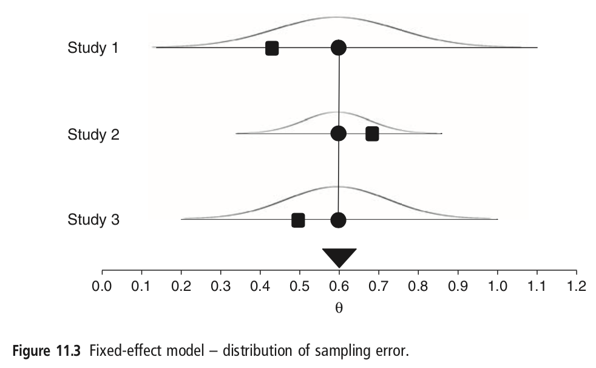

### Random effects model

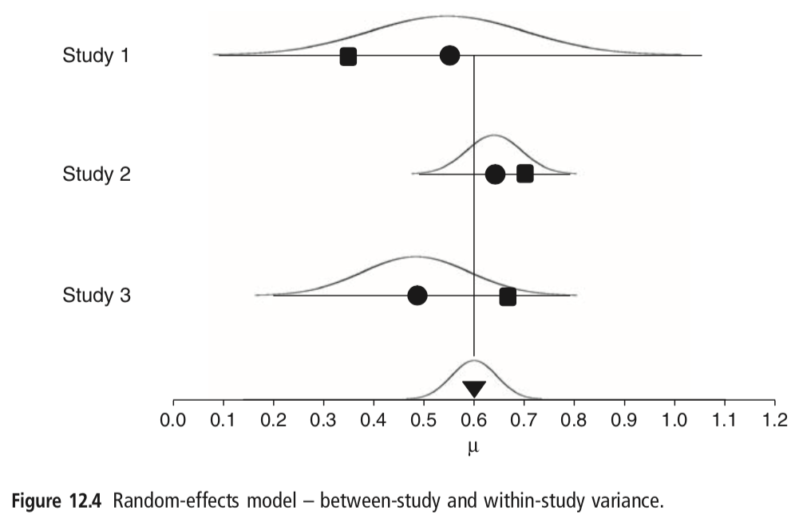

### Summary effect

Random/mixed-effects models: `rma()`

```r
result.ormr <-
  rma(ai = tpos, bi = tneg,
      ci = cpos, di = cneg,
      data = dat.bcg,
      measure = "OR")
```

`?escalc`

### rma() : method

Estimators for the amount of heterogeneity:

- “DL” = DerSimonian-Laird estimator
- “HE” = Hedges estimator
- “HS” = Hunter-Schmidt estimator
- “SJ” = Sidik-Jonkman estimator
- “ML” = maximum-likelihood estimator
- **“REML”** = restricted maximum-likelihood estimator
- “EB” = empirical Bayes estimator
- “PM” = Paule-Mandel estimator
- “GENQ” = generalized Q-statistic estimator

### Summary effect

```r
summary(result.ormr)
```

```
Random-Effects Model (k = 13; tau^2 estimator: REML)

  logLik  deviance       AIC       BIC      AICc
-12.5757   25.1513   29.1513   30.1211   30.4847

tau^2 (estimated amount of total heterogeneity): 0.3378 (SE = 0.1784)
tau (square root of estimated tau^2 value):      0.5812
I^2 (total heterogeneity / total variability):   92.07%
H^2 (total variability / sampling variability):  12.61

Test for Heterogeneity:
Q(df = 12) = 163.1649, p-val < .0001

Model Results:

estimate      se     zval    pval    ci.lb    ci.ub
 -0.7452  0.1860  -4.0057  <.0001  -1.1098  -0.3806  ***

---
Signif. codes:  0 '***' 0.001 '**' 0.01 '*' 0.05 '.' 0.1 ' ' 1
```

### Summary effect

- 使用dat.ishak2007
- 建立Random effects model

### Assess Heterogeneity

- 評估「個別論文的效果」和「綜合性效果」是否有差異性
- 異質性越高，資料的整合越難，可能會影響到分析的結論
- Higgins'I2
  - 0% to 30% Low
  - 30% to 60% Moderate
  - 50% to 90% Substantial
  - 75% to 100% Considerable

### Intra-class correlation (ICC)

```r
result.ormr$I2
```

```
[1] 92.07269
```

```r
result.ormr$H2
```

```
[1] 12.61462
```

```r
confint(result.ormr)
```

```
       estimate   ci.lb   ci.ub
tau^2    0.3378  0.1302  1.1812
tau      0.5812  0.3608  1.0868
I^2(%)  92.0727 81.7376 97.5971
H^2     12.6146  5.4757 41.6164
```

### The Forest Plot

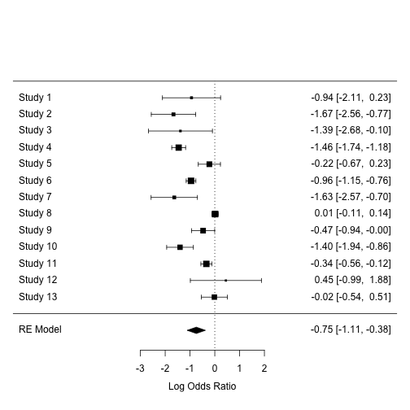

```r
forest(result.ormr) # DEFAULT PLOT
```

### The Forest Plot

- `order`: Sort by “obs”, “fit”, “prec”, etc.
- `slab`: Change study labels
- `ilab`: Add study information
- `psize`: Symbol sizes

```r
study.names <-
  letters[1:result.ormr$k]
study.year <-
  2000 + sample(0:9,
                result.ormr$k,
                replace = T)
```

### The Forest Plot

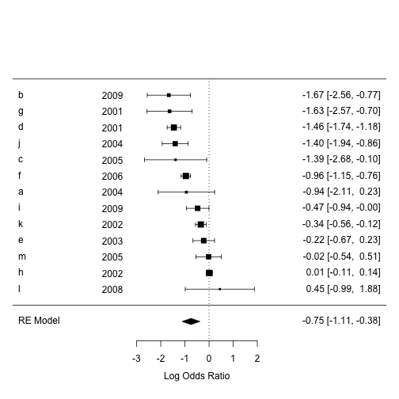

```r
forest(result.ormr,
       order = "obs",
       slab = study.names,
       ilab = study.year,
       ilab.xpos = -4)
```

### The Forest Plot

- 使用 dat.ishak2007
- 建立 Random effects model
- 畫 Forest Plot

### Subgroup analysis

檢驗綜合效果（例如：介入成效）是否因為某些變項不同而有所差異

```r
### fit random-effects model in the three subgroups
res.s <- rma(ai=tpos, bi=tneg,
             ci=cpos, di=cneg,
             data=dat.bcg, measure="OR",
             subset=(alloc=="systematic"))
res.r <- rma(ai=tpos, bi=tneg,
             ci=cpos, di=cneg,
             data=dat.bcg, measure="OR",
             subset=(alloc=="random"))
res.a <- rma(ai=tpos, bi=tneg,
             ci=cpos, di=cneg,
             data=dat.bcg, measure="OR",
             subset=(alloc=="alternate"))
```

### Subgroup analysis

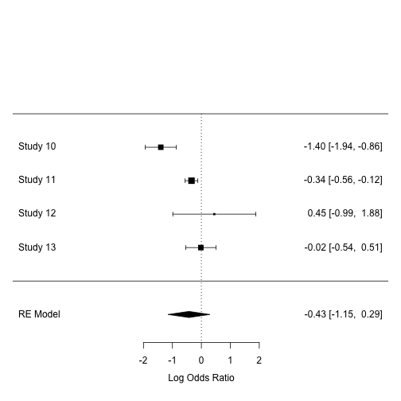

```r
forest(res.s)
```

### Subgroup analysis

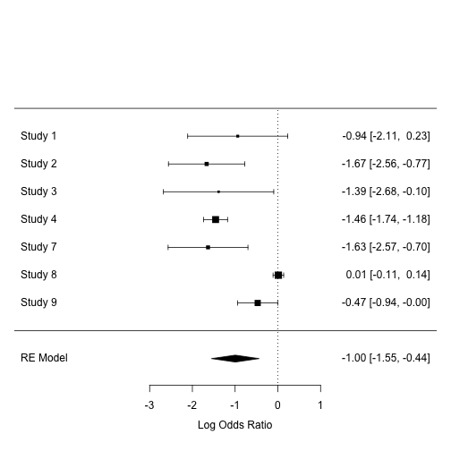

```r
forest(res.r)
```

### Subgroup analysis

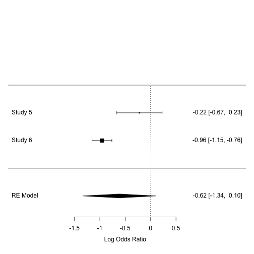

```r
forest(res.a)
```

### Subgroup analysis

- 使用dat.gibson2002
- 用type做子分群

### Sensitivity analysis

- 將某篇論文刪除後，看看剩餘論文的合併效果是否會不同，測試整體的穩定度
- 如果某篇論文被刪除後，造成綜合性效果明顯改變，就應該在論文的Discussion部分，說明這一篇論文對於分析的重要性

```r
cases <- leave1out(result.ormr)
knitr::kable(cases)
```

| estimate | se | zval | pval | ci.lb | ci.ub | Q | Qp | tau2 | I2 | H2 |
| --- | --- | --- | --- | --- | --- | --- | --- | --- | --- | --- |
| -0.7367722 | 0.1963125 | -3.753058 | 0.0001747 | -1.121538 | -0.3520068 | 162.45415 | 0 | 0.3616351 | 93.07946 | 14.449732 |
| -0.6815577 | 0.1866192 | -3.652131 | 0.0002601 | -1.047325 | -0.3157908 | 155.83244 | 0 | 0.3142239 | 92.07274 | 12.614705 |
| -0.7154986 | 0.1923533 | -3.719711 | 0.0001995 | -1.092504 | -0.3384931 | 161.07330 | 0 | 0.3464431 | 92.80794 | 13.904215 |
| -0.6634357 | 0.1860858 | -3.565215 | 0.0003636 | -1.028157 | -0.2987143 | 106.97867 | 0 | 0.2971375 | 90.53158 | 10.561429 |
| -0.7975190 | 0.1980324 | -4.027215 | 0.0000564 | -1.185655 | -0.4093827 | 162.22626 | 0 | 0.3515126 | 92.55136 | 13.425273 |
| -0.7255622 | 0.2052551 | -3.534929 | 0.0004079 | -1.127855 | -0.3232696 | 129.60540 | 0 | 0.3790937 | 91.22107 | 11.390913 |
| -0.6862593 | 0.1878567 | -3.653100 | 0.0002591 | -1.054452 | -0.3180669 | 156.79642 | 0 | 0.3202570 | 92.21927 | 12.852257 |
| -0.8284272 | 0.1859193 | -4.455843 | 0.0000084 | -1.192822 | -0.4640321 | 72.71742 | 0 | 0.2941939 | 86.78016 | 7.564388 |
| -0.7744138 | 0.2031980 | -3.811129 | 0.0001383 | -1.172675 | -0.3761530 | 163.14194 | 0 | 0.3751411 | 93.02196 | 14.330663 |
| -0.6841357 | 0.1916879 | -3.569009 | 0.0003583 | -1.059837 | -0.3084344 | 150.51661 | 0 | 0.3264348 | 92.16015 | 12.755347 |
| -0.7912461 | 0.2020236 | -3.916601 | 0.0000898 | -1.187205 | -0.3952870 | 162.31937 | 0 | 0.3646881 | 91.42509 | 11.661926 |
| -0.7934176 | 0.1882767 | -4.214105 | 0.0000251 | -1.162433 | -0.4244021 | 161.70112 | 0 | 0.3310969 | 92.50884 | 13.349076 |
| -0.8112970 | 0.1916060 | -4.234195 | 0.0000229 | -1.186838 | -0.4357562 | 160.65390 | 0 | 0.3257353 | 92.12891 | 12.704720 |

## 出版偏差評估

- Funnel plot
- Egger test
- [參考閱讀 Meta-analyses: how to read a funnel plot](https://fhs.mcmaster.ca/anesthesiaresearch/documents/Sedgwick2013Meta-analyses-howtoreadafunnelplot.pdf)

### Funnel plot

- 以漏斗圖偵測「出版偏差」
  - 研究人員通常傾向發表具有正向效果的文獻，而不傾向發表負向效果的文章
  - 某些應該存在的研究結果不容易被發現 -X軸代表風險差，Y軸代表標準差，黑點代表每一份研究，越上面的研究表示標準差越小（樣本數越大）。
- 漏斗圖如果呈現對稱，表示沒有出版偏差；若呈現不對稱，表示有出版偏差的情形，這部分要注意。

### Funnel plot

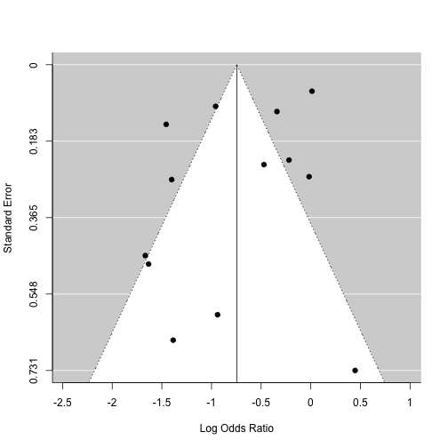

```r
funnel(result.ormr)
```

### Egger test

P通常要0.10以下

```r
regtest(result.ormr)
```

```
Regression Test for Funnel Plot Asymmetry

model:     mixed-effects meta-regression model
predictor: standard error

test for funnel plot asymmetry: z = -0.7743, p = 0.4388
```

### Trim and Fill Analysis

To estimate the number of studies missing from a meta-analysis due to the suppression of the most extreme results on one side of the funnel plot.

```r
# Only applicable for FE or RE objects
trimfill(result.ormr)
```

```
Estimated number of missing studies on the right side: 0 (SE = 2.3309)

Random-Effects Model (k = 13; tau^2 estimator: REML)

tau^2 (estimated amount of total heterogeneity): 0.3378 (SE = 0.1784)
tau (square root of estimated tau^2 value):      0.5812
I^2 (total heterogeneity / total variability):   92.07%
H^2 (total variability / sampling variability):  12.61

Test for Heterogeneity:
Q(df = 12) = 163.1649, p-val < .0001

Model Results:

estimate      se     zval    pval    ci.lb    ci.ub
 -0.7452  0.1860  -4.0057  <.0001  -1.1098  -0.3806  ***

---
Signif. codes:  0 '***' 0.001 '**' 0.01 '*' 0.05 '.' 0.1 ' ' 1
```

### Funnel plot

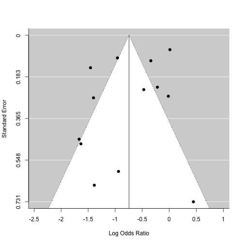

```r
funnel(trimfill(result.ormr))
```

### Funnel plot

- 使用 dat.ishak2007
- 建立 Random effects model
- 畫 Funnel plot 檢視出版偏差
- 做 Egger test 檢定出版偏差

### 總結

- 題目才是最重要的
- 搜尋與整理文獻第二重要
- 分析輔助